# Competition_MIS302_Group_1.Rmd

Onur Uyan - Beşire Nur Çelebi

2025-05-17

In today’s fast-paced and highly competitive business world, understanding market dynamics and staying ahead of competitors is crucial. Companies must constantly assess their position, recognize their strengths and weaknesses, and adapt to evolving market conditions.

This project explores key competitive and strategic factors that impact business performance. Our goal is to offer meaningful insights that support smarter decision-making and foster sustainable growth.

# 1 Objective

Our main goal is to build and compare several supervised learning models to predict whether a client will subscribe (y = ‘yes’) to a term deposit offered by the bank, and to identify which types of clients are most likely to say ‘yes’.

### 1.0.1 Research Questions

-Which customer-related features (like age, job, balance, contact history, etc.) are most helpful for predicting a subscription?

-What’s the overall subscription rate? And how does it change across different customer subgroups?

### 1.0.2 What We Did?

**Data Loading & Cleaning:** We imported the “bank-full.csv” file, checked data types, and made sure there were no missing values.

**Exploratory Data Analysis (EDA):** We calculated summary stats and conversion rates overall and by variables like job and education. Also created visualizations (histograms, bar charts, correlation matrix) to spot patterns and trends.

**Preprocessing & Sampling:** Turned the target variable into a factor, split the data into training (70%) and test (30%) sets. For quick testing, we also made a smaller 5,000-sample version.

### 1.0.3 Modeling:

**Logistic Regression:** Compared full vs reduced models using Likelihood Ratio Test(LRT)

**Support Vector Machines (SVM):** Tried linear and radial kernels, tested both standart and class-weighted versions using cross-validation.

# 2 2.Data Import & Initial Exploration

### 2.0.1 Goal

Load the full “bank-full.csv” data set and get an initial understanding of its structure, variables, and key stats.

### 2.0.2 Key Questions

-What are the variable types (numeric vs. character), and how many of each are there?

-Are there any missing values?

-What does the distribution of the target variable “y” look like?

-How many observations we have in data set?

## 2.1 Exploratory Data Analysis of Data

Data Frame Summary

bank_data

**Dimensions**: 45211 x 17  
**Duplicates**: 0

| **No** | **Variable** | **Stats / Values** | **Freqs (% of Valid)** | **Graph** | **Valid** | **Missing** |
| --- | --- | --- | --- | --- | --- | --- |
| 1 | age [integer] | Mean (sd) : 40.9 (10.6) min ≤ med ≤ max: 18 ≤ 39 ≤ 95 IQR (CV) : 15 (0.3) | 77 distinct values |  | 45211 (100.0%) | 0 (0.0%) |
| 2 | job [character] | 1. blue-collar 2. management 3. technician 4. admin. 5. services 6. retired 7. self-employed 8. entrepreneur 9. unemployed 10. housemaid [ 2 others ] | 9732 ( 21.5% ) 9458 ( 20.9% ) 7597 ( 16.8% ) 5171 ( 11.4% ) 4154 ( 9.2% ) 2264 ( 5.0% ) 1579 ( 3.5% ) 1487 ( 3.3% ) 1303 ( 2.9% ) 1240 ( 2.7% ) 1226 ( 2.7% ) |  | 45211 (100.0%) | 0 (0.0%) |
| 3 | marital [character] | 1. divorced 2. married 3. single | 5207 ( 11.5% ) 27214 ( 60.2% ) 12790 ( 28.3% ) |  | 45211 (100.0%) | 0 (0.0%) |
| 4 | education [character] | 1. primary 2. secondary 3. tertiary 4. unknown | 6851 ( 15.2% ) 23202 ( 51.3% ) 13301 ( 29.4% ) 1857 ( 4.1% ) |  | 45211 (100.0%) | 0 (0.0%) |
| 5 | default [character] | 1. no 2. yes | 44396 ( 98.2% ) 815 ( 1.8% ) |  | 45211 (100.0%) | 0 (0.0%) |
| 6 | balance [integer] | Mean (sd) : 1362.3 (3044.8) min ≤ med ≤ max: -8019 ≤ 448 ≤ 102127 IQR (CV) : 1356 (2.2) | 7168 distinct values |  | 45211 (100.0%) | 0 (0.0%) |
| 7 | housing [character] | 1. no 2. yes | 20081 ( 44.4% ) 25130 ( 55.6% ) |  | 45211 (100.0%) | 0 (0.0%) |
| 8 | loan [character] | 1. no 2. yes | 37967 ( 84.0% ) 7244 ( 16.0% ) |  | 45211 (100.0%) | 0 (0.0%) |
| 9 | contact [character] | 1. cellular 2. telephone 3. unknown | 29285 ( 64.8% ) 2906 ( 6.4% ) 13020 ( 28.8% ) |  | 45211 (100.0%) | 0 (0.0%) |
| 10 | day [integer] | Mean (sd) : 15.8 (8.3) min ≤ med ≤ max: 1 ≤ 16 ≤ 31 IQR (CV) : 13 (0.5) | 31 distinct values |  | 45211 (100.0%) | 0 (0.0%) |
| 11 | month [character] | 1. may 2. jul 3. aug 4. jun 5. nov 6. apr 7. feb 8. jan 9. oct 10. sep [ 2 others ] | 13766 ( 30.4% ) 6895 ( 15.3% ) 6247 ( 13.8% ) 5341 ( 11.8% ) 3970 ( 8.8% ) 2932 ( 6.5% ) 2649 ( 5.9% ) 1403 ( 3.1% ) 738 ( 1.6% ) 579 ( 1.3% ) 691 ( 1.5% ) |  | 45211 (100.0%) | 0 (0.0%) |
| 12 | duration [integer] | Mean (sd) : 258.2 (257.5) min ≤ med ≤ max: 0 ≤ 180 ≤ 4918 IQR (CV) : 216 (1) | 1573 distinct values |  | 45211 (100.0%) | 0 (0.0%) |
| 13 | campaign [integer] | Mean (sd) : 2.8 (3.1) min ≤ med ≤ max: 1 ≤ 2 ≤ 63 IQR (CV) : 2 (1.1) | 48 distinct values |  | 45211 (100.0%) | 0 (0.0%) |
| 14 | pdays [integer] | Mean (sd) : 40.2 (100.1) min ≤ med ≤ max: -1 ≤ -1 ≤ 871 IQR (CV) : 0 (2.5) | 559 distinct values |  | 45211 (100.0%) | 0 (0.0%) |
| 15 | previous [integer] | Mean (sd) : 0.6 (2.3) min ≤ med ≤ max: 0 ≤ 0 ≤ 275 IQR (CV) : 0 (4) | 41 distinct values |  | 45211 (100.0%) | 0 (0.0%) |
| 16 | poutcome [character] | 1. failure 2. other 3. success 4. unknown | 4901 ( 10.8% ) 1840 ( 4.1% ) 1511 ( 3.3% ) 36959 ( 81.7% ) |  | 45211 (100.0%) | 0 (0.0%) |
| 17 | y [character] | 1. no 2. yes | 39922 ( 88.3% ) 5289 ( 11.7% ) |  | 45211 (100.0%) | 0 (0.0%) |

To summarise, we have 45,211 observations and no missing values.

### 2.1.1 Variable Names and types:

We have 7 numeric and 10 categorical variables in our data set.

| Variable_name | type |
| --- | --- |
| age | Numeric |
| job | Character |
| marital | Character |
| education | Character |
| default | Character |
| balance | Numeric |
| housing | Character |
| loan | Character |
| contact | Character |
| day | Numeric |
| month | Character |
| duration | Numeric |
| campaign | Numeric |
| pdays | Numeric |
| previous | Numeric |
| poutcome | Character |
| y | Character |

# 3 3. Visualizing Data & Response Patterns

### 3.0.1 Goal

-Get a comprehensive overview of the dataset’s structure, overall conversion rate, and how subscription rates vary by key categorical features and age.

### 3.0.2 Key Questions

-What is the overall conversion rate (y = “yes”)?

-What is the response rate by job?

-What is the response rate by education levels?

-What is the age distribution of clients?

### 3.0.3 Check “y” Variable: Proportion

```
##
##        no       yes
## 0.8830152 0.1169848
```

### 3.0.4 Plot Response Rate by Job

Certain job types (e.g. “retired”, “student”) and higher-education categories have response rates above the global average; others cluster below.

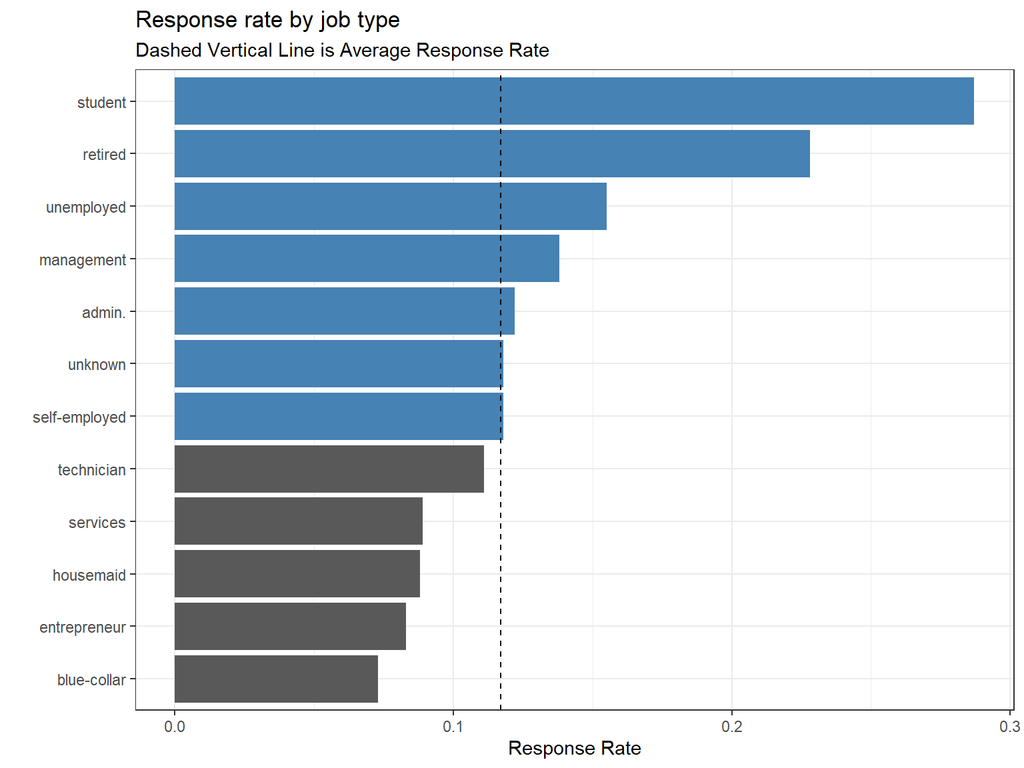

### 3.0.5 Response Rate by Education:

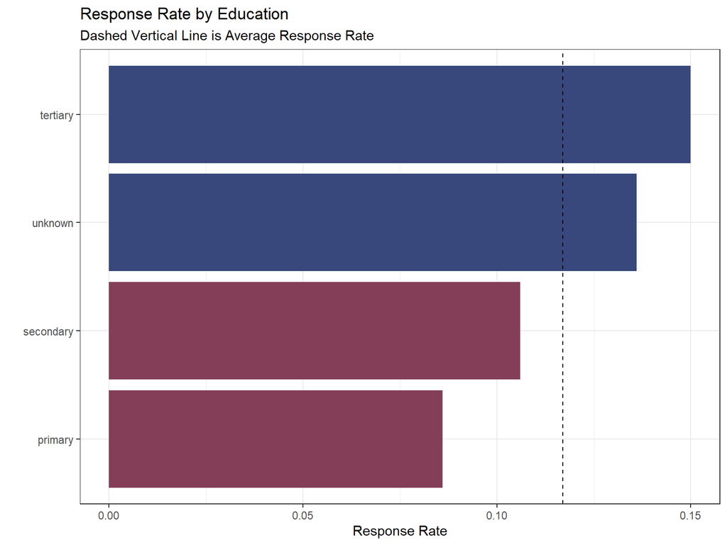

### 3.0.6 Age histograms

Age distribution is roughly bell-shaped with slight right skew, concentrated between ~25 and ~60 years.

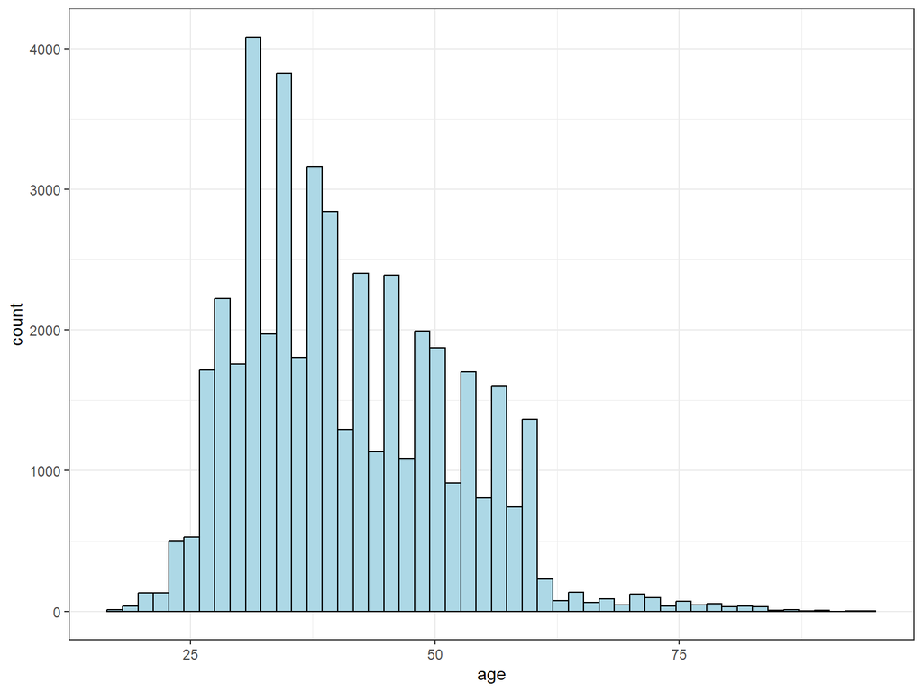

### 3.0.7 Summary of the Graphs

On the other hand, offering proposals to blue-collar workers, entrepreneurs, housemaids, or people working in the services sector with primary or secondary education usually results in rejection.

# 4 4. Data Preparation & Building Logistic Regression Models

### 4.0.1 Goal

Prepare the data set for modeling by converting the target variable into a factor and splitting the data into training and test sets. Fit a baseline logistic regression model using all available features. Then, evaluate the predictive performance of the selected (reduced) logistic regression model on unseen data.

### 4.0.2 Key Questions

-Which predictors are statistically significant when everything is included?

-What’s the overall goodness-of-fit?

-What is the test-set AUC?

# 5 Data Modelling

### 5.0.1 Prepare Data for Modeling: Convert Target & Split into Train/Test Sets

```r
# Preparing the data as 0/1 and factor
numeric_bank_data <- bank_data %>%
  mutate(y = ifelse(y == "no", 0, 1))
numeric_bank_data$y <- as.factor(numeric_bank_data$y)

# Splitting to data as train and test
set.seed(138022)
split <- sample.split(numeric_bank_data$y, SplitRatio = 0.7)

train_data <- subset(numeric_bank_data, split == TRUE)
test_data <- subset(numeric_bank_data, split == FALSE)
```

## 5.1 Creating the Models

Our first logistic regression model with unfiltered all train_data.

```
##
## Call:
## glm(formula = y ~ ., family = binomial, data = train_data)
##
## Coefficients:
##                      Estimate Std. Error z value Pr(>|z|)
## (Intercept)        -2.528e+00  2.198e-01 -11.501  < 2e-16 ***
## age                 5.484e-04  2.641e-03   0.208 0.835526
## jobblue-collar     -2.974e-01  8.696e-02  -3.420 0.000626 ***
## jobentrepreneur    -2.782e-01  1.492e-01  -1.865 0.062211 .
## jobhousemaid       -4.459e-01  1.594e-01  -2.798 0.005142 **
## jobmanagement      -1.747e-01  8.760e-02  -1.995 0.046096 *
## jobretired          2.315e-01  1.167e-01   1.983 0.047318 *
## jobself-employed   -1.929e-01  1.313e-01  -1.470 0.141575
## jobservices        -2.015e-01  1.003e-01  -2.010 0.044429 *
## jobstudent          3.902e-01  1.313e-01   2.972 0.002961 **
## jobtechnician      -1.593e-01  8.263e-02  -1.928 0.053876 .
## jobunemployed      -1.486e-01  1.315e-01  -1.130 0.258500
## jobunknown         -4.296e-01  2.692e-01  -1.596 0.110481
## maritalmarried     -1.850e-01  7.004e-02  -2.641 0.008256 **
## maritalsingle       6.345e-02  8.023e-02   0.791 0.429030
## educationsecondary  1.686e-01  7.743e-02   2.177 0.029451 *
## educationtertiary   3.913e-01  8.967e-02   4.364 1.28e-05 ***
## educationunknown    3.560e-01  1.207e-01   2.950 0.003181 **
## defaultyes         -8.931e-02  1.939e-01  -0.461 0.645105
## balance             1.581e-05  6.201e-06   2.549 0.010802 *
## housingyes         -6.502e-01  5.243e-02 -12.401  < 2e-16 ***
## loanyes            -4.573e-01  7.239e-02  -6.317 2.67e-10 ***
## contacttelephone   -2.225e-01  9.036e-02  -2.462 0.013805 *
## contactunknown     -1.586e+00  8.689e-02 -18.257  < 2e-16 ***
## day                 6.308e-03  2.990e-03   2.110 0.034861 *
## monthaug           -6.506e-01  9.441e-02  -6.891 5.55e-12 ***
## monthdec            7.791e-01  2.052e-01   3.796 0.000147 ***
## monthfeb           -8.736e-02  1.065e-01  -0.820 0.412056
## monthjan           -1.139e+00  1.448e-01  -7.865 3.70e-15 ***
## monthjul           -8.253e-01  9.346e-02  -8.831  < 2e-16 ***
## monthjun            4.535e-01  1.130e-01   4.013 6.00e-05 ***
## monthmar            1.660e+00  1.443e-01  11.498  < 2e-16 ***
## monthmay           -3.523e-01  8.664e-02  -4.066 4.78e-05 ***
## monthnov           -7.798e-01  1.005e-01  -7.762 8.33e-15 ***
## monthoct            9.128e-01  1.289e-01   7.083 1.41e-12 ***
## monthsep            9.428e-01  1.427e-01   6.607 3.92e-11 ***
## duration            4.132e-03  7.609e-05  54.298  < 2e-16 ***
## campaign           -8.610e-02  1.196e-02  -7.201 5.96e-13 ***
## pdays               1.015e-04  3.706e-04   0.274 0.784151
## previous            2.721e-03  7.041e-03   0.386 0.699150
## poutcomeother       1.471e-01  1.070e-01   1.375 0.169266
## poutcomesuccess     2.257e+00  9.885e-02  22.832  < 2e-16 ***
## poutcomeunknown    -1.033e-01  1.117e-01  -0.924 0.355270
## ---
## Signif. codes:  0 '***' 0.001 '**' 0.01 '*' 0.05 '.' 0.1 ' ' 1
##
## (Dispersion parameter for binomial family taken to be 1)
##
##     Null deviance: 22840  on 31646  degrees of freedom
## Residual deviance: 15209  on 31604  degrees of freedom
## AIC: 15295
##
## Number of Fisher Scoring iterations: 6
```

```
##
## Call:
## glm(formula = y ~ job_signif + marital_signif + education_signif +
##     balance + housing + loan + contact_signif + month_signif +
##     duration + campaign + poutcome_signif, family = binomial,
##     data = train_data)
##
## Coefficients:
##                             Estimate Std. Error z value Pr(>|z|)
## (Intercept)               -3.629e+00  1.067e-01 -34.001  < 2e-16 ***
## job_signifother            1.167e-01  6.671e-02   1.749 0.080279 .
## job_signifretired          5.509e-01  9.855e-02   5.590 2.28e-08 ***
## job_signifstudent          7.347e-01  1.279e-01   5.744 9.27e-09 ***
## marital_signifother        2.499e-01  4.479e-02   5.579 2.42e-08 ***
## education_signifsecondary  2.203e-01  7.454e-02   2.956 0.003120 **
## education_signiftertiary   4.207e-01  8.128e-02   5.176 2.27e-07 ***
## education_signifunknown    3.785e-01  1.181e-01   3.205 0.001353 **
## balance                    1.580e-05  6.020e-06   2.624 0.008692 **
## housingyes                -5.883e-01  5.027e-02 -11.703  < 2e-16 ***
## loanyes                   -5.492e-01  7.139e-02  -7.694 1.43e-14 ***
## contact_signiftelephone   -2.538e-01  8.850e-02  -2.868 0.004136 **
## contact_signifunknown     -1.627e+00  8.342e-02 -19.501  < 2e-16 ***
## month_signifdec            1.468e+00  2.004e-01   7.325 2.38e-13 ***
## month_signifjan           -3.879e-01  1.378e-01  -2.816 0.004863 **
## month_signifjun            1.093e+00  1.015e-01  10.774  < 2e-16 ***
## month_signifmar            2.334e+00  1.378e-01  16.940  < 2e-16 ***
## month_signifmay            3.074e-01  8.524e-02   3.606 0.000311 ***
## month_signifoct            1.626e+00  1.233e-01  13.187  < 2e-16 ***
## month_signifother          1.853e-01  6.861e-02   2.701 0.006913 **
## month_signifsep            1.616e+00  1.359e-01  11.889  < 2e-16 ***
## duration                   4.070e-03  7.500e-05  54.260  < 2e-16 ***
## campaign                  -9.414e-02  1.173e-02  -8.027 1.00e-15 ***
## poutcome_signifsuccess     2.359e+00  7.833e-02  30.123  < 2e-16 ***
## ---
## Signif. codes:  0 '***' 0.001 '**' 0.01 '*' 0.05 '.' 0.1 ' ' 1
##
## (Dispersion parameter for binomial family taken to be 1)
##
##     Null deviance: 22840  on 31646  degrees of freedom
## Residual deviance: 15369  on 31623  degrees of freedom
## AIC: 15417
##
## Number of Fisher Scoring iterations: 6
```

We made a logistic regression model (called model_2) to guess if someone will say yes to opening a term deposit. Like, we looked at their job, if they’re married, what kind of education they have, how much money they have in the bank, and stuff like that.

We choose logistic regression because the thing we try to guess is like yes or no, so we need something that works with binary stuff. Logistic regression does that—it tells us like what’s the chance someone says “yes” depending on other info.

Some things really matter in the model, like:

```
•   how long the call lasted (duration)

•   if they said yes before (poutcome_signifsuccess)

•   if they were contacted in March (month_signifmar)

•   if they’re a student (job_signifstudent)
```

→ These all have really low p-values, so they actually mean something.

```
•   Positive numbers:
```

If a variable has a positive number (like poutcome_signifsuccess = 2.359), that means it makes people more likely to say yes.

```
•   Negative numbers:
```

Like if they have a housing loan (housingyes = -0.588), they’re less likely to say yes.

It’s useful for:

```
•   Companies can see which kind of people are more likely to buy stuff.

•   They can call the right people at the right time (like March seems good).

•   They can make different groups of customers based on their info, and treat them different.
```

## 5.2 Model Comparison

Let’s test whether Model 2 has lower deviance than Model 1:

```r
# Comparison with ANOVA
anova(model_2, model_1, test="LRT")
```

```
## Analysis of Deviance Table
##
## Model 1: y ~ job_signif + marital_signif + education_signif + balance +
##     housing + loan + contact_signif + month_signif + duration +
##     campaign + poutcome_signif
## Model 2: y ~ age + job + marital + education + default + balance + housing +
##     loan + contact + day + month + duration + campaign + pdays +
##     previous + poutcome
##   Resid. Df Resid. Dev Df Deviance  Pr(>Chi)
## 1     31623      15369
## 2     31604      15209 19   159.78 < 2.2e-16 ***
## ---
## Signif. codes:  0 '***' 0.001 '**' 0.01 '*' 0.05 '.' 0.1 ' ' 1
```

Here we’re comparing two models with lrtest() to see which one is better. • Model 1 is the shorter one (has less variables, like job_signif, education_signif, etc.) • Model 2 is the big one (has more stuff like age, job, marital, pdays, previous etc.)

```r
# Comparison with Likelihood ratio test
lrtest(model_2, model_1)
```

```
## Likelihood ratio test
##
## Model 1: y ~ job_signif + marital_signif + education_signif + balance +
##     housing + loan + contact_signif + month_signif + duration +
##     campaign + poutcome_signif
## Model 2: y ~ age + job + marital + education + default + balance + housing +
##     loan + contact + day + month + duration + campaign + pdays +
##     previous + poutcome
##   #Df  LogLik Df  Chisq Pr(>Chisq)
## 1  24 -7684.4
## 2  43 -7604.5 19 159.78  < 2.2e-16 ***
## ---
## Signif. codes:  0 '***' 0.001 '**' 0.01 '*' 0.05 '.' 0.1 ' ' 1
```

The test gives a Chi-squared value = 159.78 with p-value < 2.2e-16, which is super small. → That means: Model 2 is statistically better than Model 1, because it explains more of the data.

But also it uses more variables, so we should check if that extra complexity is really worth it (maybe with AIC or other stuff).

In summary Model 2 is better, but also more complicated.

## 5.3 Model Evaluation

```r
# Predict to test_data using model_2.
predictions_prob <- predict(model_2, newdata = test_data, type = "response")
predictions_class <- ifelse(predictions_prob > 0.5, "1", "0")

# Accuracy report of model_2.
confusionMatrix(factor(predictions_class, levels = c("0", "1")),
                factor(test_data$y, levels = c("0", "1")))
```

```
## Confusion Matrix and Statistics
##
##           Reference
## Prediction     0     1
##          0 11713  1020
##          1   264   567
##
##                Accuracy : 0.9053
##                  95% CI : (0.9003, 0.9102)
##     No Information Rate : 0.883
##     P-Value [Acc > NIR] : < 2.2e-16
##
##                   Kappa : 0.4225
##
##  Mcnemar's Test P-Value : < 2.2e-16
##
##             Sensitivity : 0.9780
##             Specificity : 0.3573
##          Pos Pred Value : 0.9199
##          Neg Pred Value : 0.6823
##              Prevalence : 0.8830
##          Detection Rate : 0.8635
##    Detection Prevalence : 0.9387
##       Balanced Accuracy : 0.6676
##
##        'Positive' Class : 0
##
```

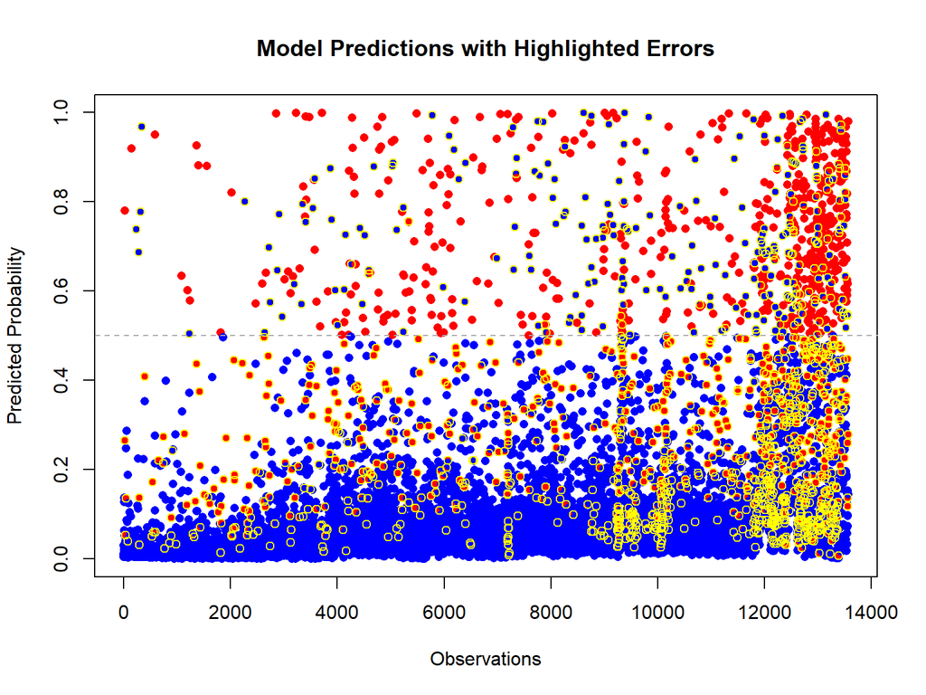

In this part, we’re trying to see how well the model is guessing who says yes or no. • The dots in the plot are each person. • Red means the real answer was “yes”, • Blue means the real answer was “no”.

Then we use the model to predict, and it gives a probability between 0 and 1 for each person.

There’s a line at 0.5 — so if the predicted value is over 0.5, model thinks it’s “yes”.

But not all guesses are right So we highlight the wrong ones in yellow circles. Those are the predictions where the model messed up.

Looks like there are a lot of yellow circles in both top and bottom parts → means model still makes some mistakes, especially for tricky cases.

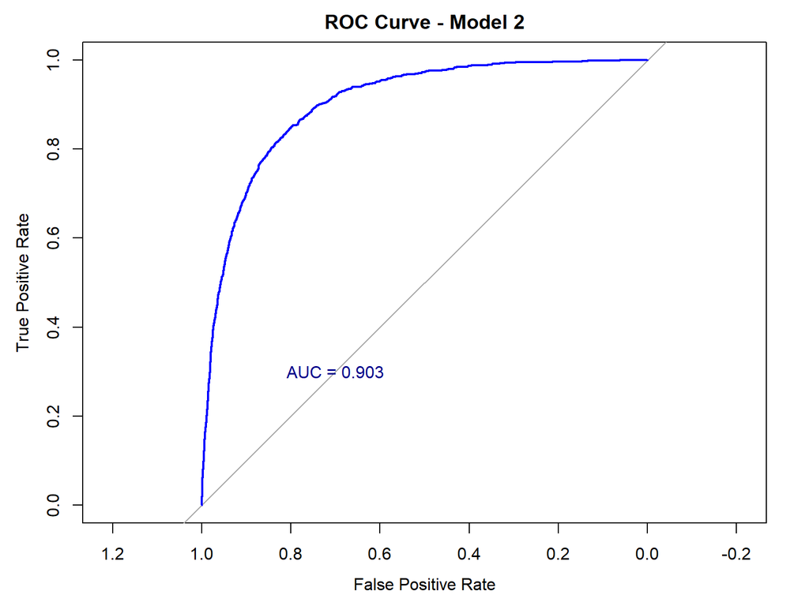

We made this ROC Curve thing to check if the model is good at guessing or not. It shows how well the model can tell the difference between people who said “yes” and “no”. • On the x-axis is False Positive Rate (like model says “yes” but it’s actually “no”) • y-axis is True Positive Rate (like model says “yes” and it’s correct)

The blue line is our model. The closer it goes to the top-left corner, the better. Here it looks pretty curvy and goes up fast → that’s good.

Also we got this AUC = 0.903 → I heard if it’s over 0.9 it means the model is really good.

## 5.4 Tree‐Based Models

### 5.4.1 Decision Tree

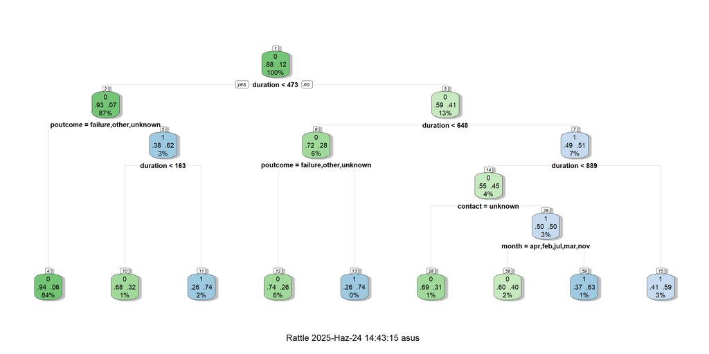

```r
# Create the decision tree model
set.seed(123)
tree_model <- rpart(y ~ ., data = train_data, method = "class")

# Visualize decision tree
fancyRpartPlot(tree_model)
```

This is a decision tree. It’s like a flowchart that helps the model decide if someone will say “yes” or “no” to the offer.

```
•   The first question is about duration (like how long the call was).
```

If it’s less than 473 seconds, most people said “no” (green = class 0).

If it’s longer, then it checks other stuff.

```
•   Then it asks about poutcome (previous campaign result),
```

and then more checks like contact type, month, and call duration again.

At the end of each branch, the tree says something like:

```
•   0.94 .06 means 94% said no, 6% said yes

•   Color: green = mostly no (0), blue = mostly yes (1)
```

So basically: • Short calls → mostly no

```
•   Long calls with good poutcome → more chance for yes

•   Also things like the month and contact type matter
```

Pretty useful how the tree just splits people like that and makes decisions based on simple rules.

# 6 Evaluation of Decision Tree

```
## Confusion Matrix and Statistics
##
##           Reference
## Prediction     0     1
##          0 11647   998
##          1   330   589
##
##                Accuracy : 0.9021
##                  95% CI : (0.897, 0.907)
##     No Information Rate : 0.883
##     P-Value [Acc > NIR] : 7.35e-13
##
##                   Kappa : 0.4203
##
##  Mcnemar's Test P-Value : < 2.2e-16
##
##             Sensitivity : 0.9724
##             Specificity : 0.3711
##          Pos Pred Value : 0.9211
##          Neg Pred Value : 0.6409
##              Prevalence : 0.8830
##          Detection Rate : 0.8587
##    Detection Prevalence : 0.9322
##       Balanced Accuracy : 0.6718
##
##        'Positive' Class : 0
##
```

This table shows how good the model is at guessing stuff.

```
•   The accuracy is 0.9021, which means the model got like 90% of the answers right.Pretty solid we think.
```

But when we look deeper:

```
•   Sensitivity (0.9724) is super high → means the model is really good at finding the people who said “no” (class 0).

•   But Specificity (0.3711) is low → so the model kind of struggles to catch the people who said “yes” (class 1).
```

Also we have something called Kappa = 0.42, which shows how better the model is compared to random guessing. It’s not perfect, but not terrible either.

Model is decent overall, but not that great at detecting class 1 (people who said yes).

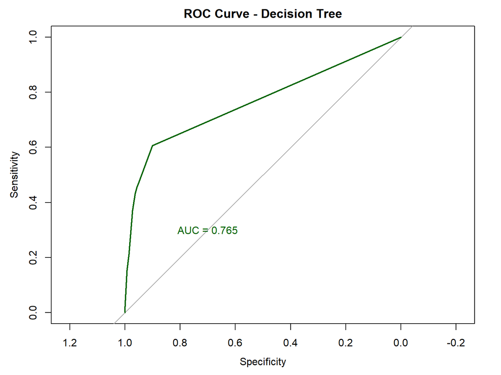

ROC curve for the decision tree model this time.

```
•   The green line shows how good the tree is at telling “yes” or “no” correctly.

•   The AUC = 0.765, which is okay-ish.
```

It’s better than random (which would be 0.5), but not as good as the logistic model we saw earlier (that one had 0.903 AUC).

Tree model works fine, but logistic regression is stronger in this case.

### 6.0.1 Dataset and Sampling

```r
# Read data
bank_data <- read.csv("bank-full.csv", sep = ";")

# Make target variable a factor
bank_data$y <- as.factor(bank_data$y)
set.seed(42)
bank_data_sample <- bank_data %>% sample_n(5000)

# Training and test set (70-30)
set.seed(1234)
train_index <- createDataPartition(bank_data_sample$y, p = 0.7, list = FALSE)
bank_train <- bank_data_sample[train_index, ]
bank_test <- bank_data_sample[-train_index, ]
```

-Column y (yes/no) is converted to factor (category) for classification problem. SVM requires a target variable of factor type for classification.

The goal of this step is to create 70% training, 30% test data.

The createDataPartition() function divides by preserving class proportions (this is good).

### 6.0.2 Lineer Kernel SVM

```
##
## Call:
## svm(formula = y ~ ., data = bank_train, kernel = "linear", probability = TRUE)
##
##
## Parameters:
##    SVM-Type:  C-classification
##  SVM-Kernel:  linear
##        cost:  1
##
## Number of Support Vectors:  854
##
##  ( 477 377 )
##
##
## Number of Classes:  2
##
## Levels:
##  no yes
```

```
## Confusion Matrix and Statistics
##
##           Reference
## Prediction   no  yes
##        no  3041  316
##        yes   54   90
##
##                Accuracy : 0.8943
##                  95% CI : (0.8837, 0.9043)
##     No Information Rate : 0.884
##     P-Value [Acc > NIR] : 0.02927
##
##                   Kappa : 0.2838
##
##  Mcnemar's Test P-Value : < 2e-16
##
##             Sensitivity : 0.9826
##             Specificity : 0.2217
##          Pos Pred Value : 0.9059
##          Neg Pred Value : 0.6250
##              Prevalence : 0.8840
##          Detection Rate : 0.8686
##    Detection Prevalence : 0.9589
##       Balanced Accuracy : 0.6021
##
##        'Positive' Class : no
##
```

```
## Confusion Matrix and Statistics
##
##           Reference
## Prediction   no  yes
##        no  1303  133
##        yes   23   40
##
##                Accuracy : 0.8959
##                  95% CI : (0.8794, 0.9109)
##     No Information Rate : 0.8846
##     P-Value [Acc > NIR] : 0.08973
##
##                   Kappa : 0.2956
##
##  Mcnemar's Test P-Value : < 2e-16
##
##             Sensitivity : 0.9827
##             Specificity : 0.2312
##          Pos Pred Value : 0.9074
##          Neg Pred Value : 0.6349
##              Prevalence : 0.8846
##          Detection Rate : 0.8692
##    Detection Prevalence : 0.9580
##       Balanced Accuracy : 0.6069
##
##        'Positive' Class : no
##
```

- We modeled the y variable with all other variables (all columns were used as independent variables)
- data = bank_train: The model is established only with training data.
- kernel = “linear”: A linear kernel is used. In other words, the decision boundary will be linear.
- It showed how many support vectors were used in the model and how many support vectors each class contains
- Estimation was made for the target variable (y) in the training and test data sets.
- These estimates were in the form of class labels (e.g. “yes”, “no”).

*Explanation:*

confusionMatrix() function gives us metrics such as:

- Accuracy
- Sensitivity / Recall
- Specificity
- F1 Score.

The results for the training set show the learning success of the model, and those for the test set show its generalizability (whether there is overfitting).

The model behaves similarly on the test set: it predicts the “no” class almost all correctly, while the “yes” class is mostly incorrectly predicted. This shows that the model is not memorizing (no overfitting) but is overly dependent on class balance.

*NOTE: Due to long knitting time, we reduced the sample size of the SVM model for this presentation.*

### 6.0.3 Weighted Linear SVM

```r
# Weighted SVM for class imbalance
svm_linear_weighted <- svm(y ~ ., data = bank_train, kernel = "linear",
                           probability = TRUE,
                           class.weights = c("no" = 1, "yes" = 5))
summary(svm_linear_weighted)
```

```
##
## Call:
## svm(formula = y ~ ., data = bank_train, kernel = "linear", probability = TRUE,
##     class.weights = c(no = 1, yes = 5))
##
##
## Parameters:
##    SVM-Type:  C-classification
##  SVM-Kernel:  linear
##        cost:  1
##
## Number of Support Vectors:  1274
##
##  ( 1055 219 )
##
##
## Number of Classes:  2
##
## Levels:
##  no yes
```

```r
# Estimation and evaluation
test_pred_weighted <- predict(svm_linear_weighted, bank_test)
confusionMatrix(test_pred_weighted, bank_test$y)
```

```
## Confusion Matrix and Statistics
##
##           Reference
## Prediction   no  yes
##        no  1167   42
##        yes  159  131
##
##                Accuracy : 0.8659
##                  95% CI : (0.8476, 0.8828)
##     No Information Rate : 0.8846
##     P-Value [Acc > NIR] : 0.9882
##
##                   Kappa : 0.4925
##
##  Mcnemar's Test P-Value : 2.791e-16
##
##             Sensitivity : 0.8801
##             Specificity : 0.7572
##          Pos Pred Value : 0.9653
##          Neg Pred Value : 0.4517
##              Prevalence : 0.8846
##          Detection Rate : 0.7785
##    Detection Prevalence : 0.8065
##       Balanced Accuracy : 0.8187
##
##        'Positive' Class : no
##
```

class.weights = c(“no” = 1, “yes” = 5) → Since the “yes” class has fewer classes, we penalized this class 5 times more. This way, the model will try to avoid incorrectly predicting the “yes” class more.

Thus, we tried to improve the performance balance between classes in imbalanced datasets.

In summary Weighted SVM successfully compensated for the class imbalance.

Prediction performance on the “yes” class has improved significantly.

Balanced metrics such as Balanced Accuracy, Specificity, Kappa increased significantly. Total accuracy (89.6% → 86.6%) decreased slightly, but this means we got a fairer and more useful model.

### 6.0.4 ROC ve AUC (Weighted SVM)

```
## Area under the curve: 0.9114
```

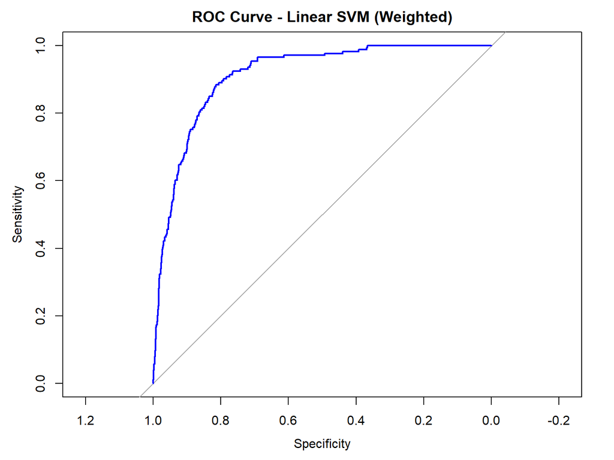

With the roc() function, we compared the probabilities predicted by the model for the “yes” class with the real classes (bank_test$y). The positive class became “yes”.

direction = “<” → Adjusted so that higher probability values are interpreted as “yes”.

*Interpretation of the Graph:*

• Y-Axis (Sensitivity / True Positive Rate): It goes from 0 to 1. In other words, the true positive rate.

*Properties of the ROC Curve:*

• The blue curve shows the performance of the model at different threshold values.

The closer the curve is to the upper left corner, the better the model performs.

• The area under the curve (AUC = Area Under Curve) is specified as approximately 0.9115.

AUC Value Comment: • AUC = 0.5: Model makes random predictions.

• AUC = 0.7 - 0.8: Acceptable model.

• AUC = 0.8 - 0.9: Good model.

• AUC > 0.9: Very good model.

For our model, AUC = 0.9115, meaning this SVM model is quite successful in terms of classification.

General Evaluation:

• ROC curve progresses close to the upper left corner: ✔️

• AUC value is high (0.9115): ✔️

• It can be said that the model is successful in terms of accuracy and balance.

### 6.0.5 Radial Kernel SVM (Cross Validation with Caret)

```
## Support Vector Machines with Radial Basis Function Kernel
##
## 3501 samples
##   16 predictor
##    2 classes: 'no', 'yes'
##
## Pre-processing: centered (42), scaled (42)
## Resampling: Cross-Validated (10 fold)
## Summary of sample sizes: 3150, 3151, 3150, 3150, 3151, 3151, ...
## Resampling results across tuning parameters:
##
##   C     ROC        Sens       Spec
##   0.25  0.8830385  0.9835202  0.1975610
##   0.50  0.8812603  0.9822267  0.2173780
##   1.00  0.8803095  0.9802892  0.2640244
##
## Tuning parameter 'sigma' was held constant at a value of 0.01802458
## ROC was used to select the optimal model using the largest value.
## The final values used for the model were sigma = 0.01802458 and C = 0.25.
```

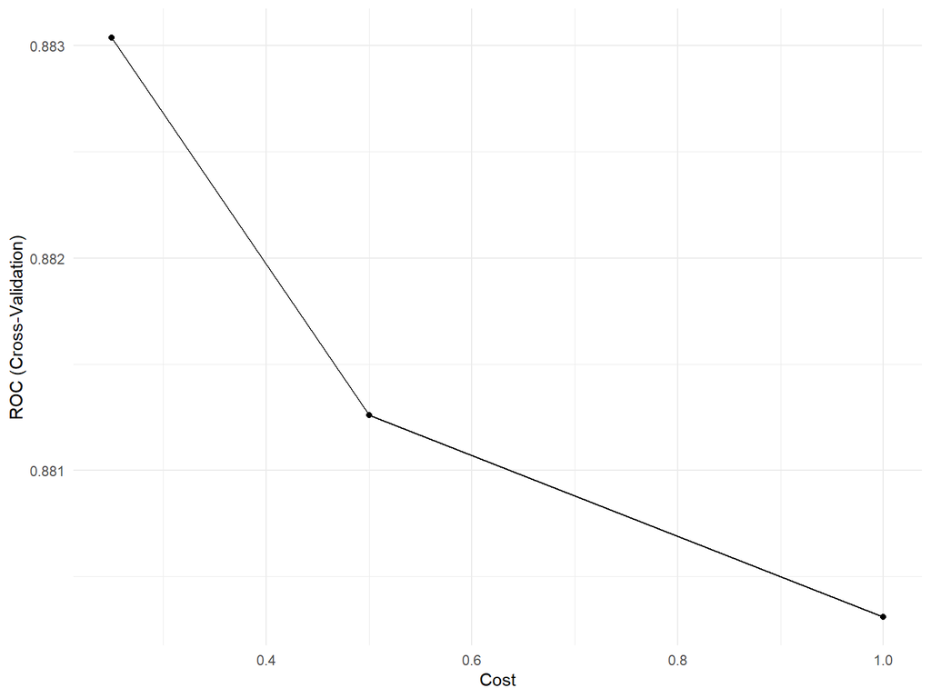

*Axis of the Graph:*

• X-Axis (Cost): C (cost) parameter that determines the error tolerance in the SVM model. Model complexity increases as it moves to the right (overfitting risk).

• Y-Axis (ROC - Cross-Validation): ROC AUC score obtained for each C value (cross-validation result).

• As the C value increases in the graph (x-axis moves to the right), the ROC score of the model decreases (y-axis decreases). This shows that overly complex models can deteriorate their performance.

• We achieved the highest performance (highest AUC score) around C = 0.25.

• The AUC score is around 0.88 at the highest point, we got a pretty good performance here.

*In summary:*

• This graph shows which value is the most appropriate when adjusting the C parameter of the SVM model.

• C = 0.25 was chosen as the optimum value because at this point the model can both classify correctly and reduce the risk of overfitting.

• We can say that a correct hyperparameter optimization was made.

### 6.0.6 Variable Importance (VIP)

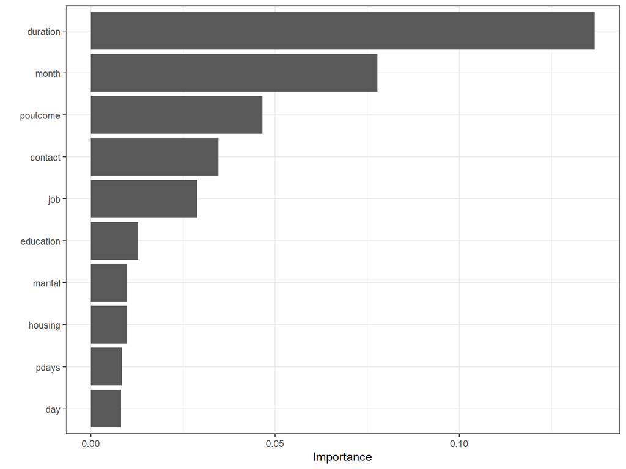

Visual Interpretation (VIP Graph)

In the graph, we see how much each variable has an impact on the model’s decision:

Horizontal axis: Contribution of each variable to AUC.

Variable with a higher value → Contributes more to the model’s classification success. (duration)

For example, since duration makes the highest contribution, the duration of the customer interview is very important in terms of prediction.

Which variables does the model’s predictive power depend on more?

Which variables should be preserved if feature engineering or dimensionality reduction is to be done?

*Our Purpose:*

To visualize how the probabilities of the “yes” class predicted by the model change as certain variables change.

duration: Call duration

age: Customer age

balance: Average balance in the bank account

### 6.0.7 1. *Type and Purpose of Graphs*

- *ROC Curves (Receiver Operating Characteristic):* ROC curves are used to measure the performance of a classification model. The X-axis shows the *False Positive Rate (FPR)* (false positive rate), and the Y-axis shows the *True Positive Rate (TPR)* (correct positive rate, sensitivity) values.
- *AUC (Area Under the Curve):* The area under the ROC curve measures the discrimination of the model. The closer the AUC value is to 1, the better the model performs. 0.5 is equivalent to random guessing.

# 7 Conclusions

*Key Findings*

*-Model Performance:*

Campaign-sensitive months (e.g., March, October) and prior success (“poutcome”) were key categorical drivers.

*Recommendations*

-For Marketing Strategy:

Optimize Call Timing: Longer calls (>300s) correlate with higher conversions; consider revising call scripts or agent training to sustain engagement.

To wrap up, our analysis highlights the importance of closely tracking competitors and market trends to maintain a competitive edge. The effective use of internal resources, continuous innovation, and well-crafted strategic planning are essential for long-term success.

Businesses that embrace change and act proactively are more likely to strengthen their market position and achieve lasting performance improvements.